# The Real Housewives of Bayesian Statistics

Linna Henry

# Diamonds and Divorce Lawyers

The real housewives is a television series that follows wealthy womens everyday lives. Througout the show, we’ve seen women get married, have children, and we’ve also seen them divorce. We cheer for these women at their high points, but as viewers we are often even more bewitched by the drama of their divorce. When Camille Grammar’s “tossed salads and scrambled eggs” singing husband Kelsey said the show was a parting gift to her before their divorce, audiences watched the dissolution of their marriage on the first season of Real Housewives of Beverly Hills. Like Camille, other housewives such as Gina Kirschenheiter and Jules Wainstein are speculated to have joined the show just to get divorced. A television show is a great tool to observe a husband’s behavior and also hear what the court of public opinion is saying about your marraige. Most wives also make a handsome wage from the show, which gives some extra security to leave their marriage.

Still other housewives divorces come as a total shock. After watching these women and being shown intimate glimpses into their lives, we become so attached to them. I vividly remember NeNe and Gregg’s fight at the kitchen counter over $300,000 in season 3. Another bombshell divorce was Ramona and Mario. After watching them go on dates, experience an albeit ficticious pregnancy scare, and renewing their vows, the couple divorced after six seasons on the show. Even Vicki and Donn’s divorce came as a suprise to me. Donn notoriously couldn’t fill up Vicki’s “love tank”, however fans like myself were still rooting for the couple. Especially after watching Vicki’s close friend Tamra divorce the season before, it felt like that would have motivated Vicki even more to work on her marriage. Fans hopeful for a happy marriage were let down in season 6 of Real Housewives of Orange Country when Vicki and Donn divorced.

This isn’t to say that all wives go to divorce court. Over the seasons we’ve seen plenty of happy marriages. We watched Lisa Vanderpump renew her vows to Ken Todd on the show, breaking the vow-renewal-divorce curse. Kandi Burruss met and married her now husband on The Real Housewives of Atlanta, and the couple went on to have two kids together. Even an entire franchise, Dallas, has not seen any divorces play out on the show yet, and all the women are married. However some Dallas women have come on to the show with a divorce already under their belt.

Real housewives is not the first show to be hit by the reality tv divorce curse. Other shows like Jessica Simpson’s Newlyweds and Britney Spears’s Chaotic also led to the couples’ divorces. It is not farfetched to think that the housewives either come on the show to get divorced, or the strain of being on tv eventually causes a divorce. All of this begs the question, when is a housewife most likely to get divorced? Do we see more housewives getting divorced in their first season like Gina and Jules? Or are they more likely to experience divorce in their later seasons? Does likelihood of divorce decrease over a wife’s tenure on the show? Let’s see.

# Tenure and Divorce

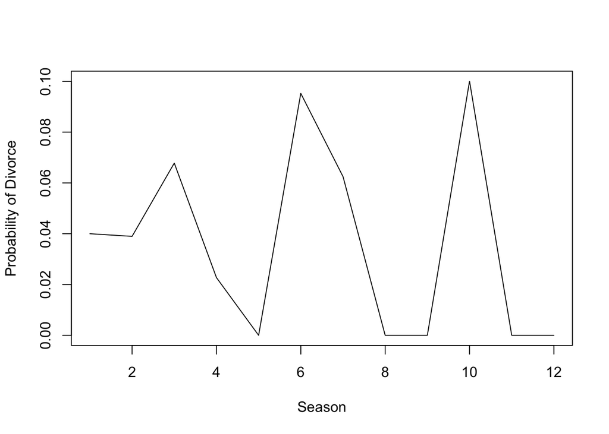

If you’re wondering if a housewife is more likely to get divorced in their first season or later in their run, it appears the latter is more likely.  
Although housewives have a whirlwind first season which sometimes includes divorce, every single housewife has a first season which minimizes the gravity of one season divorces. Season 6 and Season 10 have the highest likelihood of divorce with 9.5% and 10% respectfully of wives who make it to those seasons getting divorced. Ramona and Vicki are the two tenured wives bringing up the season 6 likelihood. Teresa Guidice is the only housewife to be separated after season 10 of The Real Housewives of New Jersey. She holds the title for most seasons under her belt before leaving her husband, Joe Guidice.

No housewives get divorced in their 5th, 8th, 9th, and 11th season. Some stalwart housewives that are keeping these numbers at 0 are Melissa Gorga, Teresa’s siter in law, Sheree Whitfield, who came into the show post divorce but did not divorce on the show, and Lisa Rinna who hardly shows her marriage on the show.

The following reveals an even deeper look at trends by city.

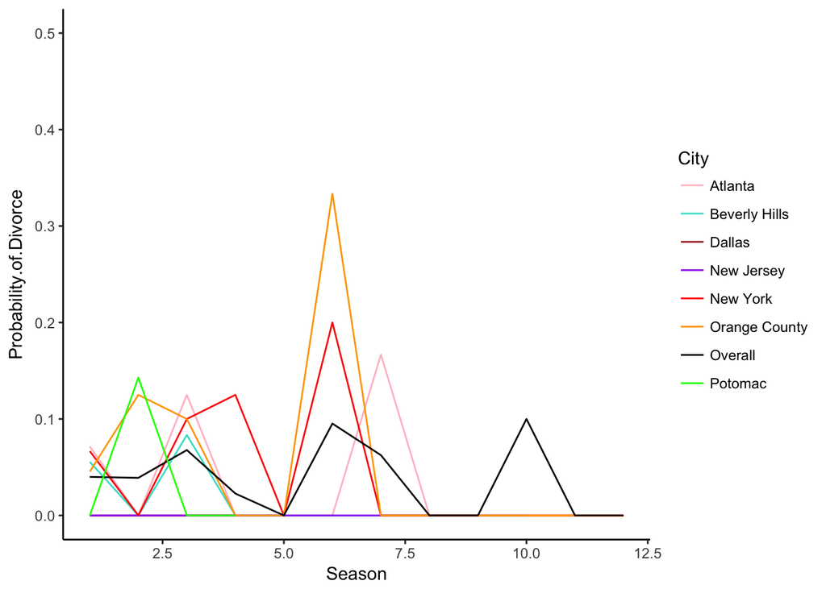

Interestingly, no Beverly Hills cast members get divorced if they can make it to 4 seasons on the show. This is good news for Dorit Kemsley who is currently in her 4th season.

This does beg the question of what is more likely in general to happen to a housewife? Divorce or leaving the show?

# Tenure and Job Security

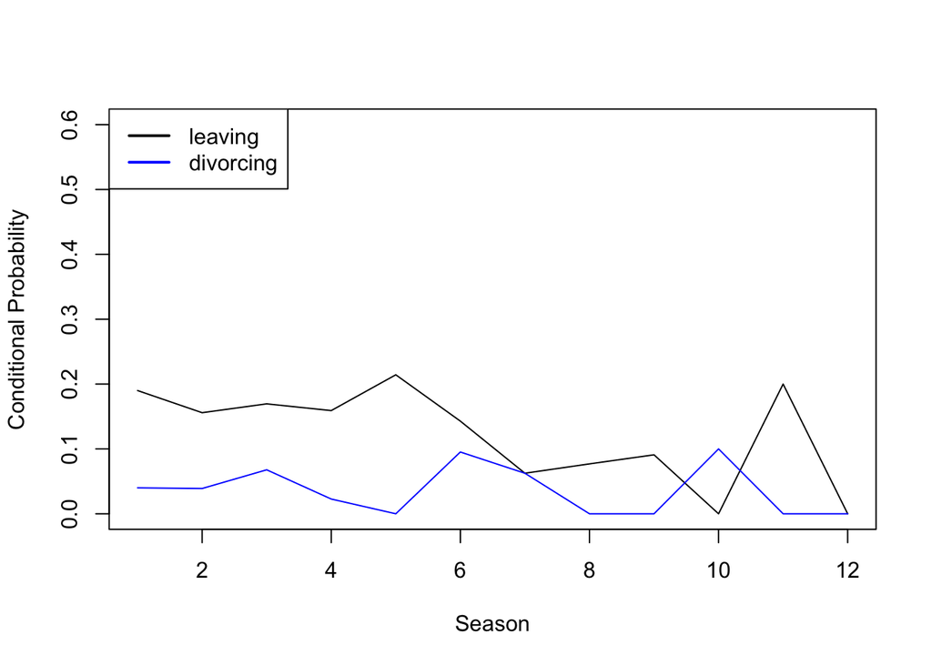

We haven’t seen a 5th season of Dallas yet, but with Leanne’s departure the likelihood of a wife leaving Dallas the longer they stay on the show is increasing. If the trend continues, Brandi and/or Stephanie won’t be on the show after season 5. Oh well.

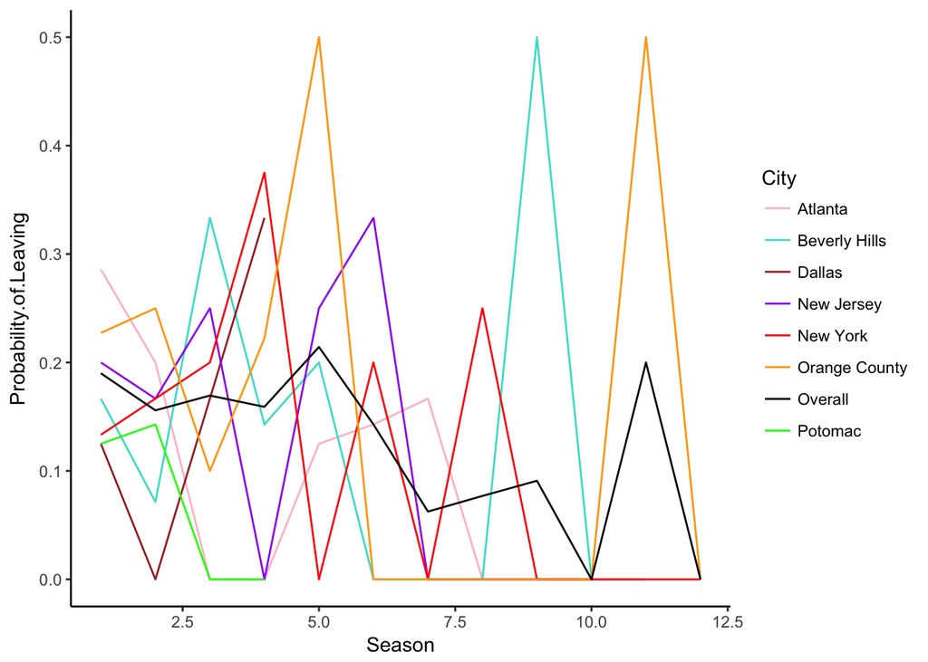

Breaking down the probability of leaving the show by city shows that New York is pushing up the season 4 likelihood of leaving the show. New York completely overhauled their cast during season 4 removing 2 original cast members, Jill Zarin and Alex McCord as well as Kelly Bensimone and Cindy Barshop who left after their 3rd and 1st season respectively. Tinsely Mortimer, who recently departed the big apple franchies, was also on the show for 4 seasons.

In Atlanta, if you can make it 8 seasons on the show you’re not likely at all to leave. Kenya Moore and Porsha Williams just finished their 7th season on the show, so hopefully we’ll be seeing more of them. There is a similar trend for Jersey, wives who make it to past 7 seasons on the show have higher staying power.

What about wives that divorce after their time on the show?

# Divorce Post Housewives

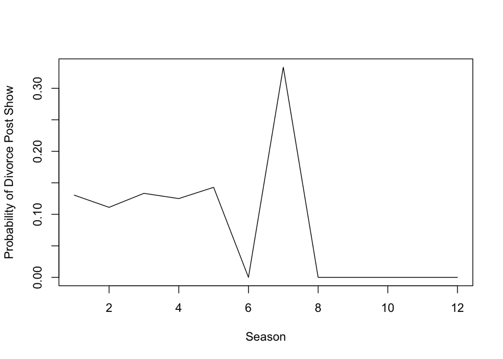

Not only are you more likely to leave the show after your 5th season, you’re also more likely to get divorced post your 5th and final season. Really the only wife that falls into this bucket is Jeana Keough. There’s also a massive spike at season 7. Again, only one housewife represents staying this long on the show and also getting divorced after her 7th season. Can you guess who it is? If you guessed Phaedra Parks, you’re correct. Although we know that making it to season 8 in Atlanta is a coveted saftey net, it also means for Kenya and Porsha to not return would increase their likelihood of getting divorced after the show. We’ve already witnessed Kenya’s shakey marriage on the past season of the show. However if these two can make it to season 8, they will likely not only have job security but they will also have marriage security. Out of all the housewives that make it to season 8, none of them get divorced post show.

Ok and the wives who were already divorced before coming on the show?

# Divorce Pre Housewives

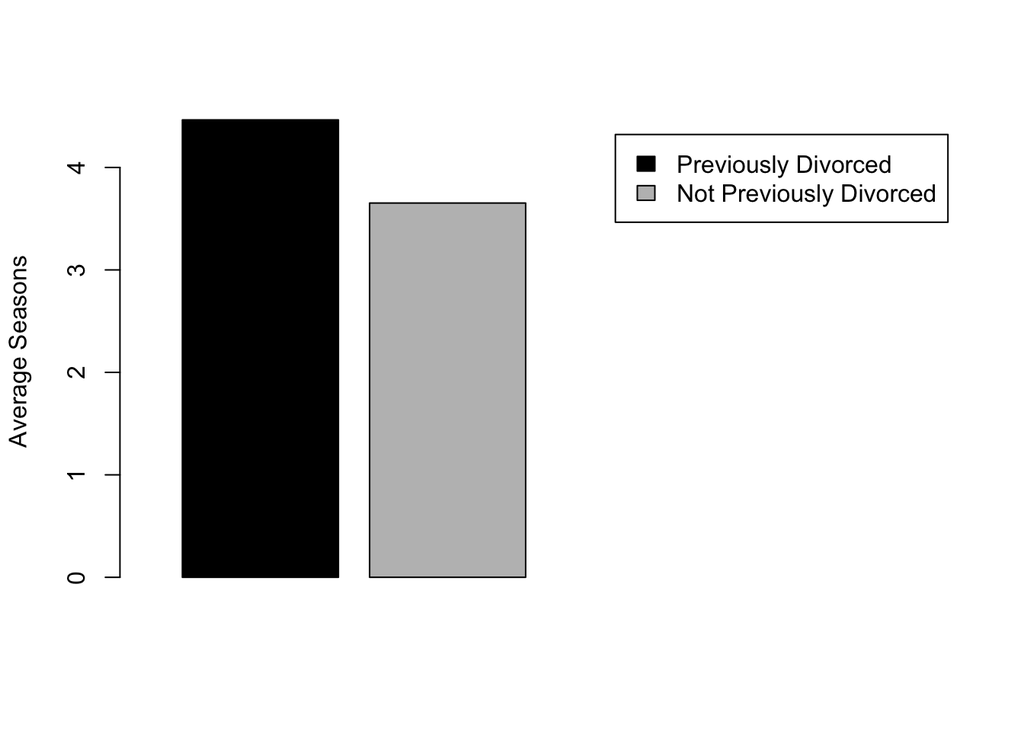

Housewives who are already divorced before they come on the show stay on the show for an average of about 1 season longer than their unwed and undivorced counter parts. Some wives that are bringing this average up are Kim Richards, Sonja Morgan, and Bethenny Frankel who had a brief marriage long before her horrific marriage to Jason Hoppy.

Some wives who did not come into the show with a divorce, and who may leave the show early because of it are Candiace Dillard Bassett, Kameron Westcott, and hopefully, Teddi Mellencamp.

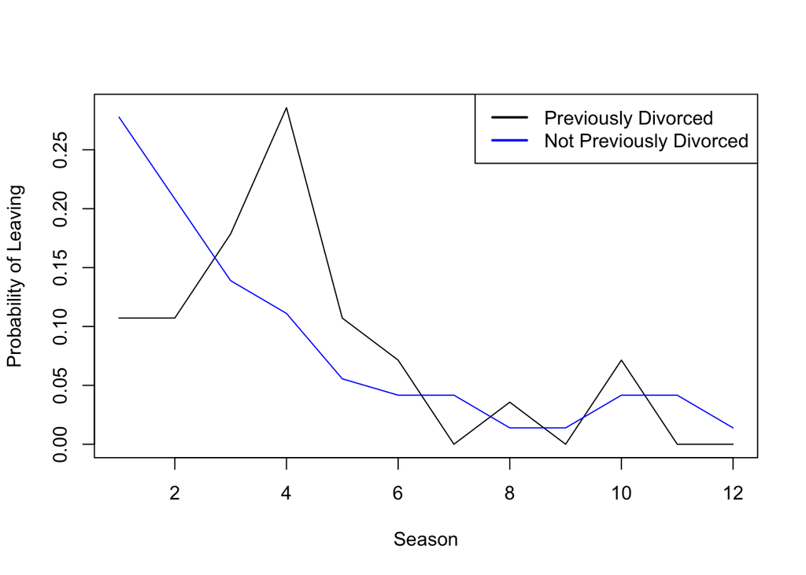

Whether or not you came into the show with a divorce can shape the landscape of your staying power for your 1st-4th seasons quite dramatically. If you came into the show with a divorce, your likelihood of leaving the show increases with each consecutive season. Conversely, entering the show without a divorce decreases your likelihood of leaving after each season. Eventhough the average time a wife is on the show without being divorced is shorter, it still stands that if a wife can make it to their 3rd or 4th season, and she didn’t have a divorce before hand, she has more staying power at that point than her previously divorced counter part. Some housewives who should be alarmed at the likelihood of leaving the show after their 4th season having already had a divorce are Kelly Dodd, who had a brief marriage before her marriage to Michael which also ended in divorce. Dolores Catania is also at risk to make it to her 5th season.

# The End

I’ve always been curious about ways to marry two things I love: stats and housewives and this analysis was a fun way to accomplish that. As much as I thought I knew about the housewives, these data helped uncover even more fascinating trends for me and insights into what might happen in the near future!

For fun, and incase I’m ever asked to be a Real Housewife, here are some of my stats inspired taglines:

I know a lot about normally distributed data, but theres nothing normal about me.

I bring a whole new meaning to the words high powered.

You might say I’m one in a million, but I’m more significant than that.

*all said while holding a calculator in the intro